# Modeling Boston with xgboost and fastshap

Bruce Hartman

University of St. Francis

2026-08-13 Revised 2026-10-06T19:08:26

Abstract

We present some `tidymodels` modeling of the Boston dataset using `xgboost` and interpret it with `vip` and `pre`.

# Introduction

We are going to estimate a model using `xgboost`, a black-box method, for the Boston dataset. Then we try to make it explainable with a surrogate, including RuleFit (with `pre`). We will also compute variable importances with Shapley values using `fastshap`

The motivation to provide RuleFit surrogates and interpretation with Shapley values for importance comes from (Molnar, 2025).

Here we use a `tidymodels` workflow for the estimation.

# Packages

As usual, we have some standard packages.

```r
library(ISLR2) #data
library(mbadtools) # some extra ggplot functions
conflicted::conflict_prefer_matching("select|filter", "dplyr", quiet=TRUE)
# interpretability
source("gg_interpret.R")
library(vip)
conflicted::conflicts_prefer(vip::vi, .quiet=TRUE) # the other vi() is a text editor
library(pdp)
library(pre)
# library(fastshap) # included in `vip`
```

# Data

We’ll use the `Boston` dataset from the `ISLR2` package.

```r
data("Boston")
Boston %>% skim
```

```
── Data Summary ────────────────────────
                           Values
Name                       Piped data
Number of rows             506
Number of columns          14
_______________________
Column type frequency:
  numeric                  14
________________________
Group variables            None
```

|  | skim_variable | n_missing | complete_rate | mean | sd | p0 | p25 | p50 | p75 | p100 | hist |
| --- | --- | --- | --- | --- | --- | --- | --- | --- | --- | --- | --- |
| 1 | crim | 0 | 1 | 3.61352356 | 8.6015451 | 0.00632 | 0.082045 | 0.25651 | 3.677083 | 88.9762 | ▇▁▁▁▁ |
| 2 | zn | 0 | 1 | 11.36363636 | 23.3224530 | 0.00000 | 0.000000 | 0.00000 | 12.500000 | 100.0000 | ▇▁▁▁▁ |
| 3 | indus | 0 | 1 | 11.13677866 | 6.8603529 | 0.46000 | 5.190000 | 9.69000 | 18.100000 | 27.7400 | ▇▆▁▇▁ |
| 4 | chas | 0 | 1 | 0.06916996 | 0.2539940 | 0.00000 | 0.000000 | 0.00000 | 0.000000 | 1.0000 | ▇▁▁▁▁ |
| 5 | nox | 0 | 1 | 0.55469506 | 0.1158777 | 0.38500 | 0.449000 | 0.53800 | 0.624000 | 0.8710 | ▇▇▆▅▁ |
| 6 | rm | 0 | 1 | 6.28463439 | 0.7026171 | 3.56100 | 5.885500 | 6.20850 | 6.623500 | 8.7800 | ▁▂▇▂▁ |
| 7 | age | 0 | 1 | 68.57490119 | 28.1488614 | 2.90000 | 45.025000 | 77.50000 | 94.075000 | 100.0000 | ▂▂▂▃▇ |
| 8 | dis | 0 | 1 | 3.79504269 | 2.1057101 | 1.12960 | 2.100175 | 3.20745 | 5.188425 | 12.1265 | ▇▅▂▁▁ |
| 9 | rad | 0 | 1 | 9.54940711 | 8.7072594 | 1.00000 | 4.000000 | 5.00000 | 24.000000 | 24.0000 | ▇▂▁▁▃ |
| 10 | tax | 0 | 1 | 408.23715415 | 168.5371161 | 187.00000 | 279.000000 | 330.00000 | 666.000000 | 711.0000 | ▇▇▃▁▇ |

[output cut: 4 more lines]

# Workflow with `tidymodels`

There are multiple steps. Set a seed for reproducibility.

```r
set.seed(2025)
```

# Data

We looked at the `Boston` dataset before.

# Crossvalidation split

Split the data into training and test datasets. We use an 80-20 split.

```r
set.seed(2025)
split <- initial_split(Boston, prop = 0.8, strata = medv)  # medv is the outcome
train_data <- training(split)
test_data  <- testing(split)
```

# Recipe

This is a basic approach. The recipe creates the formula and the data in a standard manner. It also allows some modification such as scaling and removing variables with little variance, that is almost constant and therefore unable to affect anything.

No fancy preprocessing, but center/scale numeric predictors. Most AI models work better with scaled predictors (drivers). Model `medv` using all other variables.

```r
boston_recipe <- recipe(medv ~ ., data = train_data) %>%
  step_nzv(all_predictors()) %>%  # remove near-zero variance if any
  step_normalize(all_numeric_predictors()) # center & scale numeric predictors
```

# Black-Box Model

We model with `xgboost`, a popular and quite good model. The modeling code is in the `parsnip` package.

```r
xg_spec <- boost_tree() %>%
  set_engine("xgboost") %>%
  set_mode("regression")

xg_workflow <- workflow() %>%
  add_model(xg_spec) %>%
  add_recipe(boston_recipe)

# Fit linear model on training data
xg_fit <- xg_workflow %>% fit(data = train_data)
```

# Evaluate Metrics

```r
xg_pred <- predict(xg_fit, test_data) %>%
  bind_cols(test_data) %>%
  rename(.pred = .pred)
```

```r
xg_metrics <- xg_pred %>% metrics(truth = medv, estimate = .pred)
xg_metrics
```

| .metric | .estimator | .estimate |
| --- | --- | --- |
| rmse | standard | 3.3503577 |
| rsq | standard | 0.8884481 |
| mae | standard | 2.4809140 |

The model achieved almost 89% r-squared and an rmse of 3.35 thousand dollars.

# Variable importance

For interpretation of ‘black box’ models we need to do something to explain the predictions. Read (Molnar, 2025) for more on interpretability calculations. One such is variable importance.

Extract `parsnip` fit object. Get a common data object to plot by using `vip::vi` for the model, and use model-agnostic permutation importances instead of those automatically done by the `xgboost` model.

We need to construct a prediction function for the `xgboost` result. This function works for a `tidymodels` workflow, a `parsnip` model, or a raw `xgboost` model.

```r
# Permutation-based variable importance

pred_wrapper <- function(object, newdata) {
  # If it's a workflow (parsnip + recipe)
  if (inherits(object, "workflow")) {
    # Make sure you pass a data.frame with all predictor columns
    predict(object, new_data = newdata) %>%
      dplyr::pull(.pred)
  }
  # If it's a parsnip model_fit
  else if (inherits(object, "model_fit")) {
    predict(object, new_data = newdata) %>%
      dplyr::pull(.pred)
  }
  # If it's a raw xgboost Booster
  else if (inherits(object, "xgb.Booster")) {
    predict(object, as.matrix(newdata)) %>%
      dplyr::pull(.pred)
  } else {
    stop("Unsupported object type for pred_wrapper")
  }
}
```

Now we calculate permutation importances using `vip`. Randomization in the permutations requires setting a seed for reproducibility.

```r
set.seed(123)

xg_vi_perm <- vi(
  xg_fit,
  method = "permute",
  train = train_data,
  target = "medv",
  metric = "rmse",
  nsim = 5,
  pred_wrapper=pred_wrapper,
  smaller_is_better = TRUE
)

# View results
xg_vi_perm
```

| Variable | Importance | StDev |
| --- | --- | --- |
| lstat | 6.38736629 | 0.135204802 |
| rm | 4.50272771 | 0.203942984 |
| dis | 2.18454897 | 0.074496642 |
| nox | 1.75187573 | 0.145127438 |
| crim | 1.49831368 | 0.122632014 |
| age | 1.01974308 | 0.063333563 |
| tax | 0.86995803 | 0.039295646 |
| ptratio | 0.66722804 | 0.059174849 |
| black | 0.42774695 | 0.019745610 |
| indus | 0.24235667 | 0.023785024 |

[output cut: 3 more lines]

We plot the vip.

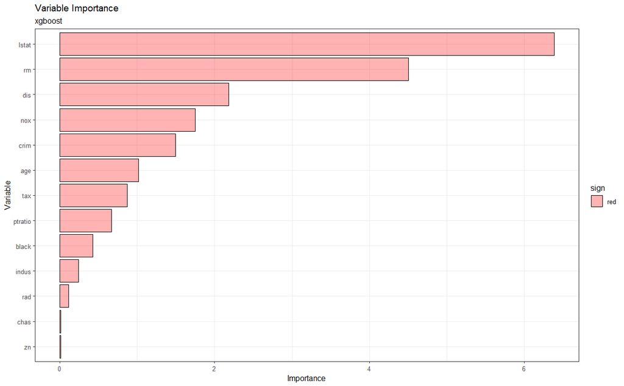

```r
xg_vi_perm %>% gg_vip() + labs(subtitle="xgboost")
```

`lstat` and `rm` are the most important variables in the model. Remember that xgboost is based on random choices, so you could get different importances with another run.

# Partial dependence

Partial dependence plots show the marginal effect of a feature (or two) on the predicted outcomes. (Molnar, n.d.)

Find the 2 top variables from the black-box model:

```r
top_var_xg <- xg_vi_perm$Variable[1:2]
cat("\nxgboost Top variables by importance: ", top_var_xg)
```

```
xgboost Top variables by importance:  lstat rm
```

Partial dependence plots on the top two variables, using `pdp` to extract the proper data. Construct the data for plotting:

```r
# use pdp to get data to plot
xg_fit_obj <- extract_fit_parsnip(xg_fit)$fit

pd_xg1 <- pdp::partial(object=xg_fit, pred.var = "lstat",
                   train = train_data,
                   pred.fun = pred_wrapper,
                   plot=FALSE)

pd_xg2 <- pdp::partial(xg_fit, pred.var = "rm",
                   train = train_data,
                   pred.fun = pred_wrapper,
                   plot=FALSE)
```

Plot the constructed data frames. Rug plots, to show the density of the axis variables, are a good idea, according to (Molnar, Chapter 19).

I like the dot plots better. We put the plots side by side.

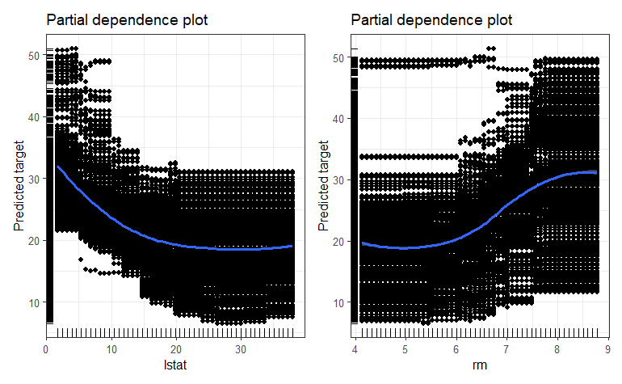

```r
wrap_plots(ncol=2,
      gg_pdp(pd_xg1),
      gg_pdp(pd_xg2)
      )
```

The relation is clearly not linear for the black-box model. The plot shows a steady decline till a break at an `lstat` of about 1 sd above the mean, when it flattens out. That value of `lstat` is 19.7941248, or around 20%. For `rm` the plot is an S curve going up between 6.5 and 7.5 rooms.